# Lecture 15: K-Means Clustering

### The Elbow method

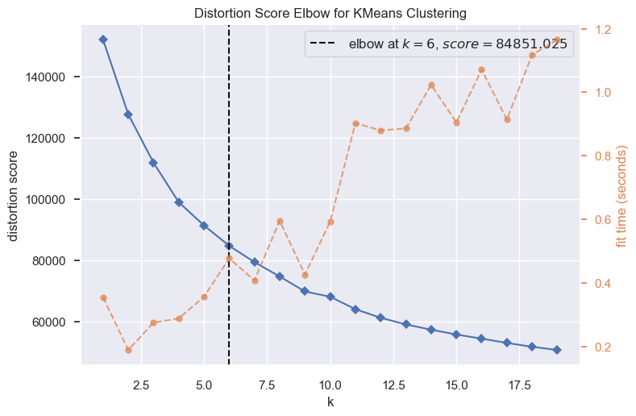

```python
model = KMeans(random_state=42)
visualizer = KElbowVisualizer(model, k=(1, 20))

visualizer.fit(transformed_df)  # Fit the data to the visualizer
visualizer.show();
```

- The optimal number of clusters is not as clear as it was in our toy example.
- Let's examine Silhouette scores.

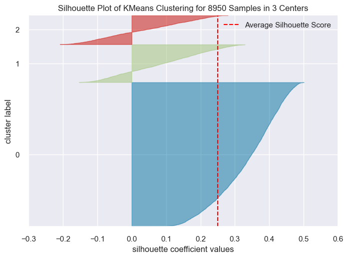

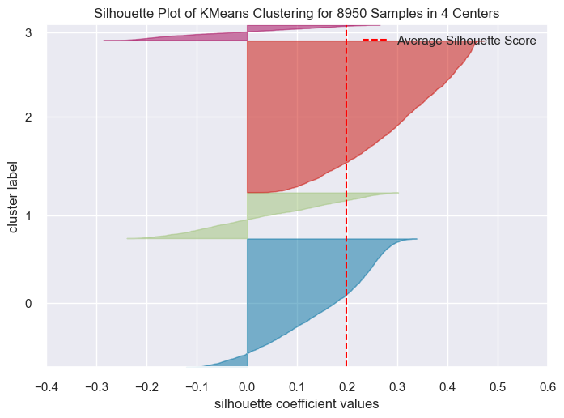

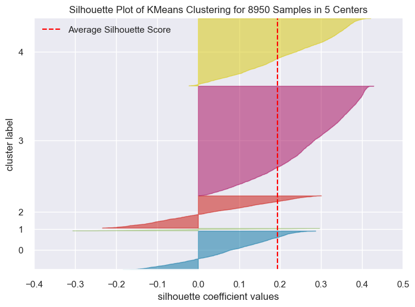

```python
for k in range(3, 6):
    model = KMeans(k, random_state=42)
    visualizer = SilhouetteVisualizer(model, colors="yellowbrick")
    visualizer.fit(transformed_df)  # Fit the data to the visualizer
    visualizer.show()
```

- I'm going to run `KMeans` with `n_clusters = 4`.
- You can try out `n_clusters = 5` and `n_clusters = 6` on your own.

### Visualizing clusters

- Can we visualize the clusters?
- We have a high dimensional data and we need to reduce the dimensionality in order to visualize it.
- Let's reduce the dimensionality using a technique called [UMAP](https://umap-learn.readthedocs.io/en/latest/index.html).

To run the code below, you'll have to install the `umap-learn` package either with `conda` or `pip`, as described in the [documentation](https://umap-learn.readthedocs.io/en/latest/index.html).

```
> conda install -c conda-forge umap-learn
```

or

```
> pip install umap-learn
```

```python
import umap
```

```python
def plot_umap_clusters(
    data,
    cluster_labels,
    size=50,
    n_neighbors=15,
    title="UMAP visualization",
):
    """
    Carry out dimensionality reduction using UMAP and plot 2-dimensional clusters.

    Parameters
    -----------
    data : numpy array
        data as a numpy array
    cluster_labels : list
        cluster labels for each row in the dataset
    size : int
        size of points in the scatterplot
    n_neighbors : int
        n_neighbors hyperparameter of UMAP. See the documentation.
    title : str
        title for the visualization plot

    Returns
    -----------
    None. Shows the clusters.
    """

    reducer = umap.UMAP(n_neighbors=n_neighbors)
    Z = reducer.fit_transform(data)  # reduce dimensionality
    umap_df = pd.DataFrame(data=Z, columns=["dim1", "dim2"])
    umap_df["cluster"] = cluster_labels

    labels = np.unique(umap_df["cluster"])

    fig, ax = plt.subplots(figsize=(10, 7))
    ax.set_title(title)

    scatter = ax.scatter(
        umap_df["dim1"],
        umap_df["dim2"],
        c=umap_df["cluster"],
        cmap="tab20b",
        s=size,
        edgecolors="k",
        linewidths=0.1,
    )

    legend = ax.legend(*scatter.legend_elements(), loc="best", title="Clusters")
    ax.add_artist(legend)

    plt.show()
```

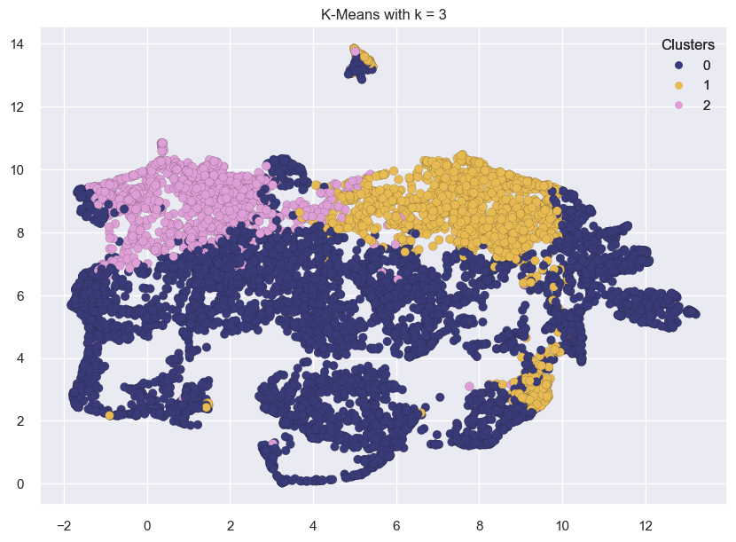

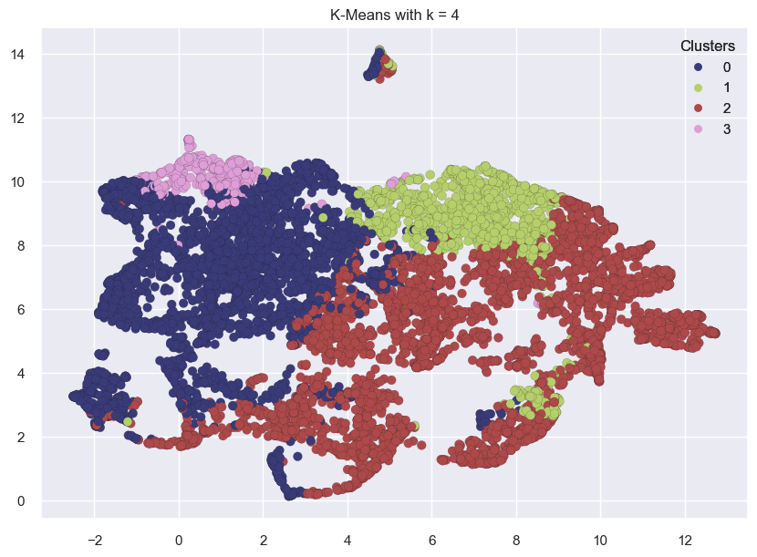

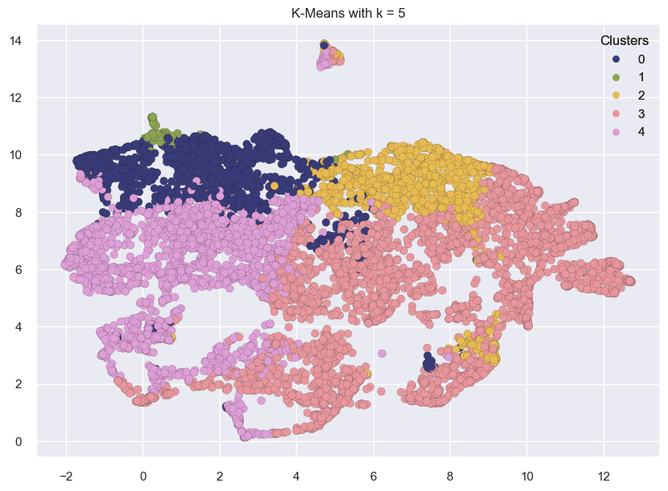

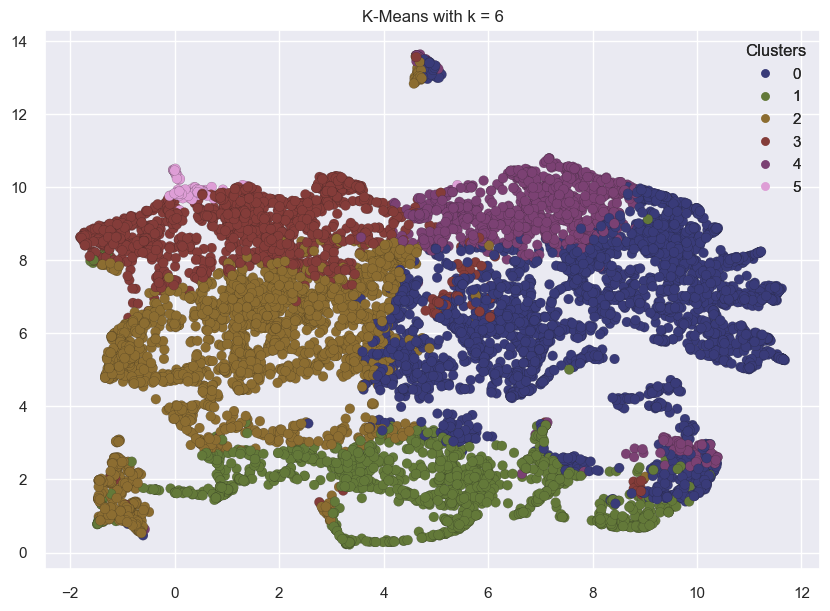

```python
for k in range(3, 7):
    kmeans = KMeans(n_clusters=k, random_state=42)
    kmeans.fit(transformed_df)
    labels = kmeans.labels_
    plot_umap_clusters(transformed_df, kmeans.labels_, title=f"K-Means with k = {k}")
```

- The clusters above look reasonably well separated.
- This might not always be the case.

### Cluster interpretation

- Let's examine the cluster centers for k=4 and identify types of customers.

```python
reasonable_k = 4
kmeans = KMeans(n_clusters=reasonable_k, random_state=42)
kmeans.fit(transformed_df)
labels = kmeans.labels_
```

```python
cluster_centers = pd.DataFrame(
    data=kmeans.cluster_centers_, columns=[transformed_df.columns]
)
cluster_centers
```

|  | ONEOFF_PURCHASES | BALANCE_FREQUENCY | PAYMENTS | CASH_ADVANCE | CREDIT_LIMIT | PURCHASES | PRC_FULL_PAYMENT | MINIMUM_PAYMENTS | PURCHASES_TRX | PURCHASES_INSTALLMENTS_FREQUENCY | TENURE | PURCHASES_FREQUENCY | CASH_ADVANCE_FREQUENCY | CASH_ADVANCE_TRX | INSTALLMENTS_PURCHASES | BALANCE | ONEOFF_PURCHASES_FREQUENCY |
| --- | --- | --- | --- | --- | --- | --- | --- | --- | --- | --- | --- | --- | --- | --- | --- | --- | --- |
| 0 | 0.000926 | 0.242574 | -0.138502 | -0.366373 | -0.077298 | 0.109044 | 0.395041 | -0.091844 | 0.296985 | 0.874138 | 0.057744 | 0.983721 | -0.462599 | -0.360303 | 0.255904 | -0.321688 | 0.317153 |
| 1 | -0.163914 | 0.384753 | 0.603821 | 1.688972 | 0.838968 | -0.234638 | -0.406367 | 0.490910 | -0.283580 | -0.450201 | -0.097146 | -0.504848 | 1.745948 | 1.617143 | -0.253747 | 1.459578 | -0.212939 |
| 2 | -0.230500 | -0.368944 | -0.262060 | -0.182691 | -0.334417 | -0.343190 | -0.258866 | -0.119249 | -0.474987 | -0.714246 | -0.052972 | -0.797823 | -0.101500 | -0.164607 | -0.387798 | -0.265552 | -0.389437 |
| 3 | 2.713251 | 0.462694 | 1.919096 | -0.155091 | 1.429882 | 3.125845 | 0.454703 | 0.477421 | 3.003251 | 1.065918 | 0.324140 | 1.136338 | -0.319096 | -0.170458 | 2.406470 | 0.954485 | 1.798653 |

- Recall that we have applied imputation and scaling on the dataset.
- But we would be able to interpret these clusters better if the centers are in the original scale.
- So let's apply inverse transformations to get the cluster center values in the original scale.

```python
data = (
    preprocessor.named_transformers_["pipeline"]
    .named_steps["standardscaler"]
    .inverse_transform(cluster_centers[numeric_features])
)
```

```python
org_cluster_centers = pd.DataFrame(data=data, columns=numeric_features)
org_cluster_centers = org_cluster_centers.reindex(
    sorted(org_cluster_centers.columns), axis=1
)
org_cluster_centers
```

|  | BALANCE | BALANCE_FREQUENCY | CASH_ADVANCE | CASH_ADVANCE_FREQUENCY | CASH_ADVANCE_TRX | CREDIT_LIMIT | INSTALLMENTS_PURCHASES | MINIMUM_PAYMENTS | ONEOFF_PURCHASES | ONEOFF_PURCHASES_FREQUENCY | PAYMENTS | PRC_FULL_PAYMENT | PURCHASES | PURCHASES_FREQUENCY | PURCHASES_INSTALLMENTS_FREQUENCY | PURCHASES_TRX | TENURE |
| --- | --- | --- | --- | --- | --- | --- | --- | --- | --- | --- | --- | --- | --- | --- | --- | --- | --- |
| 0 | 894.907458 | 0.934734 | 210.570626 | 0.042573 | 0.790021 | 4213.207678 | 642.478274 | 650.167072 | 593.974874 | 0.297070 | 1332.194205 | 0.269258 | 1236.178934 | 0.885165 | 0.711842 | 22.091773 | 11.594595 |
| 1 | 4602.462714 | 0.968415 | 4520.724309 | 0.484526 | 14.284641 | 7546.957050 | 181.607404 | 2008.251157 | 320.373681 | 0.138934 | 3481.145990 | 0.034859 | 501.896219 | 0.287731 | 0.185516 | 7.661102 | 11.387312 |
| 2 | 1011.751528 | 0.789871 | 595.759339 | 0.114833 | 2.125503 | 3277.703165 | 60.386625 | 586.301239 | 209.853863 | 0.086281 | 974.505090 | 0.078001 | 269.973466 | 0.170146 | 0.080578 | 2.903421 | 11.446429 |
| 3 | 3551.153761 | 0.986879 | 653.638891 | 0.071290 | 2.085575 | 9696.943765 | 2587.208264 | 1976.815179 | 5095.878826 | 0.739031 | 7288.739497 | 0.286707 | 7681.620098 | 0.946418 | 0.788060 | 89.359413 | 11.951100 |

```python
cluster_labels = {0: "Transactors", 1: "Revolvers", 2: "Low activity", 3: "VIP/Prime"}
org_cluster_centers["cluster_labels"] = list(cluster_labels.values())
```

```python
relevant_cols = [
    "cluster_labels",
    "BALANCE",
    "CREDIT_LIMIT",
    "PRC_FULL_PAYMENT",
    "PURCHASES_FREQUENCY",
    "CASH_ADVANCE",
    "CASH_ADVANCE_FREQUENCY",
    "CASH_ADVANCE_TRX",
]
org_cluster_centers[relevant_cols]
```

|  | cluster_labels | BALANCE | CREDIT_LIMIT | PRC_FULL_PAYMENT | PURCHASES_FREQUENCY | CASH_ADVANCE | CASH_ADVANCE_FREQUENCY | CASH_ADVANCE_TRX |
| --- | --- | --- | --- | --- | --- | --- | --- | --- |
| 0 | Transactors | 894.907458 | 4213.207678 | 0.269258 | 0.885165 | 210.570626 | 0.042573 | 0.790021 |
| 1 | Revolvers | 4602.462714 | 7546.957050 | 0.034859 | 0.287731 | 4520.724309 | 0.484526 | 14.284641 |
| 2 | Low activity | 1011.751528 | 3277.703165 | 0.078001 | 0.170146 | 595.759339 | 0.114833 | 2.125503 |
| 3 | VIP/Prime | 3551.153761 | 9696.943765 | 0.286707 | 0.946418 | 653.638891 | 0.071290 | 2.085575 |

One way to interpret and label the clusters above is as follows.

#### Transactors

- Credit card users who pay off their balance every month with least amount of interest charges.
- They are careful with their money.
- They have lowest balance and cash advance

#### Revolvers

- Credit card users who pay off only part of their monthly balance. They use credit card as a loan.
- They have highest balance and cash advance, high cash advance frequency, low purchase frequency, high cash advance transactions, low percentage of full payment
- Their credit limit is also high. (Lucrative group for banks 😟.)

#### Low activity

- There is not much activity in the account. It has low balance and not many purchases.
- Credit card users who have low credit limit.

#### VIP/Prime

- Credit card users who have high credit limit.
- They have high one-off purchases frequency, high number of purchase transactions.
- They have high balance but they also have higher percentage of full payment, similar to transactors
- Target for increase credit limit (and increase spending habits)

### More on interpretation of clusters

- In real life, you'll look through all features in detail before assigning meaning to clusters.
- This is not that easy, especially when you have a large number of features and clusters.
- One way to approach this would be visualizing the distribution of feature values for each cluster.
- Some domain knowledge would definitely help at this stage.

```python
creditcard_df['cluster'] = labels
```

Let's check the cluster assignment for the customer who made the maximum cash advance transaction.

```python
creditcard_df[creditcard_df["CASH_ADVANCE"] == max_cash_advance]
```

|  | CUST_ID | BALANCE | BALANCE_FREQUENCY | PURCHASES | ONEOFF_PURCHASES | INSTALLMENTS_PURCHASES | CASH_ADVANCE | PURCHASES_FREQUENCY | ONEOFF_PURCHASES_FREQUENCY | PURCHASES_INSTALLMENTS_FREQUENCY | CASH_ADVANCE_FREQUENCY | CASH_ADVANCE_TRX | PURCHASES_TRX | CREDIT_LIMIT | PAYMENTS | MINIMUM_PAYMENTS | PRC_FULL_PAYMENT | TENURE | cluster |
| --- | --- | --- | --- | --- | --- | --- | --- | --- | --- | --- | --- | --- | --- | --- | --- | --- | --- | --- | --- |
| 2159 | C12226 | 10905.05381 | 1.0 | 431.93 | 133.5 | 298.43 | 47137.21176 | 0.583333 | 0.25 | 0.5 | 1.0 | 123 | 21 | 19600.0 | 39048.59762 | 5394.173671 | 0.0 | 12 | 1 |

```python
def show_hists(df=creditcard_df, cols=["BALANCE", "CASH_ADVANCE"]):
    for i in cols:
        plt.figure(figsize=(35, 5))
        for j in range(4):
            plt.subplot(1, 4, j + 1)
            cluster = df[df["cluster"] == j]
            cluster[i].hist(bins=20)
            plt.title(f"{i}    \nCluster: {cluster_labels[j]} ")

        plt.show()
```

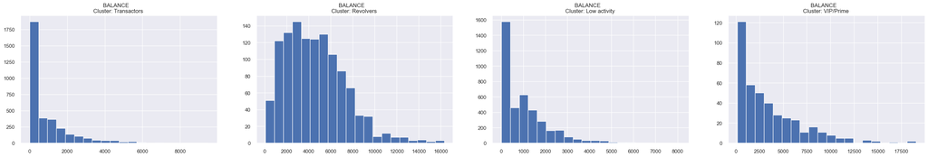

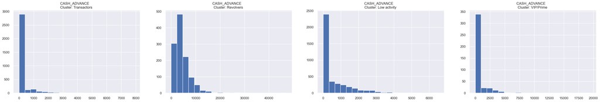

```python
show_hists() # Examining clusters for two features.
```

```python
# Uncomment the code below to show histograms for all features.
# cols = creditcard_df_cluster.columns.to_list()
# cols.remove('CUST_ID')
# cols.remove('cluster')
# show_hists(creditcard_df_cluster, cols)
```

### Practice exercise for you

- Try out different values for `n_clusters` in `KMeans` and examine the clusters.
- If you are feeling adventurous, you may try customer segmentation on [All Lending Club loan data](https://www.kaggle.com/wordsforthewise/lending-club).

## Final comments, summary, and reflection

### A comment on initialization

- The initialization of K-Means is stochastic, can this affect the results?
  - Yes! Big time.
- Let's look at an example.

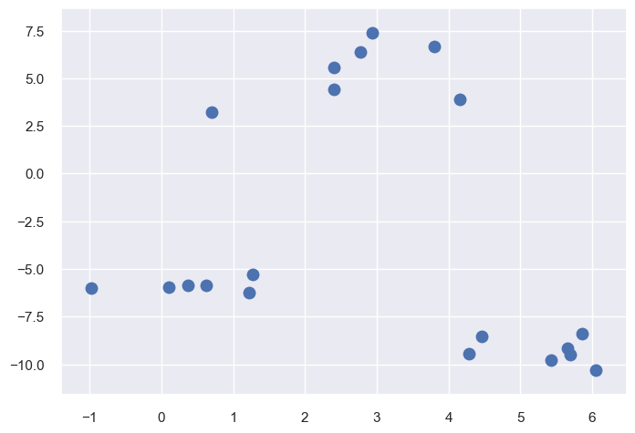

```python
X, y = make_blobs(n_samples=20, centers=3, n_features=2, random_state=10)
mglearn.discrete_scatter(X[:, 0], X[:, 1], markers="o");
```

```python
k = 3
n_examples = X.shape[0]
toy_df = pd.DataFrame(X, columns=["feat1", "feat2"])
```

### Example: Bad initialization

```python
np.random.seed(seed=10)
centroids_idx = np.random.choice(range(0, n_examples), size=k)
centroids = X[centroids_idx]
```

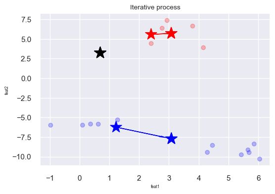

```python
plot_iterative(toy_df, centroids)
```

### Example: Better initialization

The following initialization seems much better.

```python
np.random.seed(seed=2)
centroids_idx = np.random.choice(range(0, n_examples), size=k)
centroids = X[centroids_idx]
```

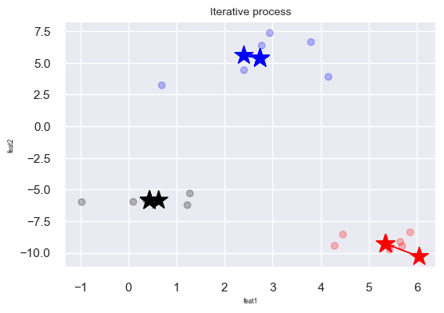

```python
plot_iterative(toy_df, centroids)
```

### What can we do about it?

- One strategy is to run the algorithm several times.
  - Check out `n_init` parameter of [`sklearn`'s `KMeans`](https://scikit-learn.org/stable/modules/generated/sklearn.cluster.KMeans.html).
- Is it possible to pick `K` in a smart way?
  - Yes! We can use the so-called [K-Means++](http://ilpubs.stanford.edu:8090/778/1/2006-13.pdf).
  - Intuitively, it picks the initial centroids which are far away from each other.
  - In other words, K-Means++ gives more chance to select points that are far away from centroids already picked.
  - By default `sklearn` uses this strategy for initialization.

### Important points to remember

- Clustering is a common unsupervised approach to identify underlying structure in data and grouping points based on similarity.
- K-Means is a popular clustering algorithm.

### Important points to remember

**K-Means**

- It requires us to specify the number of clusters in advance.
- Each example is assigned to one (and only one) cluster.
- The labels provided by the algorithm have no actual meaning.
- The centroids live in the same space as of the dataset but they are **not** actual data points, but instead are average points.
- It always converges. Convergence is dependent upon the initial centers and it may converge to a sub-optimal solution.

### Important points to remember

- Two ways to provide insight into how many clusters are reasonable for the give problem are: **the Elbow method** and **the Silhouette method**.
- Some applications of K-Means clustering include data exploration, feature engineering, customer segmentation, and document clustering.
- It takes fair amount of manual effort and domain knowledge to interpret clusters returned by K-Means.

## Resources

- ["Spaghetti Sauce" talk by Malcom Gladwell](https://www.ted.com/talks/malcolm_gladwell_on_spaghetti_sauce?language=en)
- [Visualizing-k-means-clustering](https://www.naftaliharris.com/blog/visualizing-k-means-clustering/)
- [Visualizing K-Means algorithm with D3.js](http://tech.nitoyon.com/en/blog/2013/11/07/k-means/)
- [Clustering with Scikit with GIFs](https://dashee87.github.io/data%20science/general/Clustering-with-Scikit-with-GIFs/)
- [`sklearn` clustering documentation](https://scikit-learn.org/stable/modules/clustering.html)